# **k-means**

Xavier Vivancos García

2020-12-14

# 1 Preparación

Leemos y normalizamos los datos.

```r
# Load libraries
library(tidyverse)
library(factoextra)
library(GGally)
library(gridExtra)

# Read data
data <- read.csv("https://raw.githubusercontent.com/xavivg91/machine-learning/main/kmeans/wine.csv")

# Normalization
dataNorm <- as.data.frame(scale(data))
```

## 1.1 Ejecución

```r
# Reproducible results
set.seed(800)

# Execution of k-means with k=2
data_k2 <- kmeans(dataNorm, centers=2)
```

El *output* nos proporciona la siguiente información acerca de la partición:

- `cluster`. Vector que nos indica el clúster asociado a cada observación.
- `centers`. Posiciones de los centroides.
- `size`. Número de observaciones en cada clúster.

```r
# Cluster to which each point is allocated
data_k2$cluster
```

```
##   [1] 1 1 1 1 1 1 1 1 1 1 1 1 1 1 1 1 1 1 1 1 1 1 1 1 1 1 1 1 1 1 1 1 1 1 1 1 1
##  [38] 1 1 1 1 1 1 1 1 1 1 1 1 1 1 1 1 1 1 1 1 1 1 2 2 2 2 1 2 1 1 2 2 1 2 1 2 1
##  [75] 1 2 2 2 1 1 1 1 2 2 1 1 2 2 2 2 2 2 2 1 1 1 2 1 1 1 1 2 2 2 2 2 2 2 2 1 1
## [112] 2 2 2 2 2 2 2 2 2 1 1 2 2 1 2 2 2 2 2 2 2 2 2 2 2 2 2 2 2 2 2 2 2 2 2 2 2
## [149] 2 2 2 2 2 2 2 2 2 2 2 2 2 2 2 2 2 2 2 2 2 2 2 2 2 2 2 2 2 2
```

```r
# Cluster centers
data_k2$centers
```

```
##      Alcohol Malic_Acid        Ash Ash_Alcanity  Magnesium Total_Phenols
## 1  0.3721486 -0.3349656  0.1064264   -0.5057521  0.3681732     0.8158522
## 2 -0.3325583  0.2993309 -0.0951044    0.4519487 -0.3290058    -0.7290594
##   Flavanoids Nonflavanoid_Phenols Proanthocyanins Color_Intensity        Hue
## 1  0.8525367           -0.6127493       0.6569408     -0.07666558  0.5278251
## 2 -0.7618413            0.5475632      -0.5870535      0.06850967 -0.4716735
##        OD280    Proline Customer_Segment
## 1  0.7219820  0.6558981       -0.8265217
## 2 -0.6451754 -0.5861217        0.7385938
```

```r
# Cluster size
data_k2$size
```

```
## [1] 84 94
```

Adicionalmente, también podemos consultar las siguientes métricas:

- `betweenss`. Varianza entre grupos. Suma de las distancias entre centroides. En una segmentación óptima, este valor debe ser lo más grande posible, ya que nos interesa obtener clústers alejados.
- `withinss`. Varianza dentro de grupos. Suma de las distancias entre cada punto del clúster y su centroide. En una segmentación óptima, este valor debe ser lo más pequeño posible, puesto que nos interesa que las observaciones dentro de un mismo grupo sean cercanas. `withinss`nos devuelve una varianza por cada clúster.
- `tot.withinss`. Suma de las varianzas dentro de grupos.
- `totss`. Suma de `betweenss` y `withinss`.

```r
# Between-cluster sum of squares
data_k2$betweenss
```

```
## [1] 759.0369
```

```r
# Within-cluster sum of squares
data_k2$withinss
```

```
## [1] 739.5817 979.3814
```

```r
# Total within-cluster sum of squares
data_k2$tot.withinss
```

```
## [1] 1718.963
```

```r
# Total sum of squares
data_k2$totss
```

```
## [1] 2478
```

## 1.2 ¿Cuántos clústers?

El siguiente gráfico nos representa la varianza entre grupos y dentro de grupos en función del número de clústers escogidos.

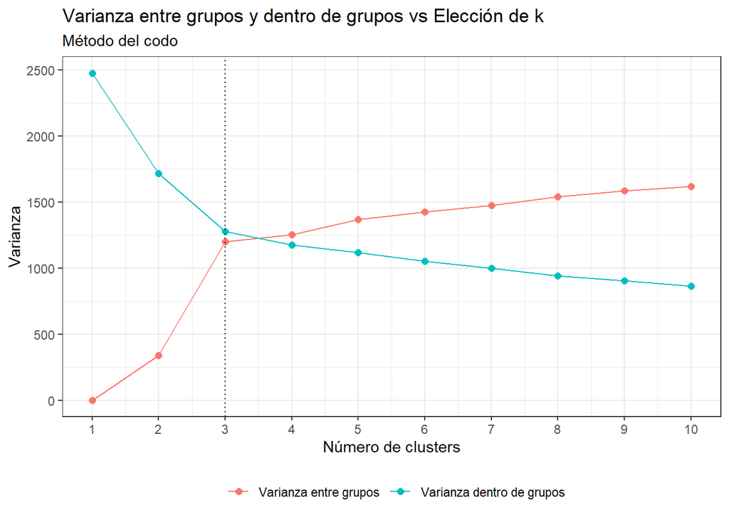

```r
bss <- numeric()
wss <- numeric()

# Reproducible results
set.seed(800)

# Run the algorithm for different values of k
for(i in 1:10){

  # For each k, calculate betweenss and tot.withinss
  bss[i] <- kmeans(dataNorm, centers=i)$betweenss
  wss[i] <- kmeans(dataNorm, centers=i)$tot.withinss

}

df <- data.frame(k=1:10, bss, wss)
df <- df %>%
  gather(Varianzas, Valores, 2:3) %>%
  mutate(Varianzas=fct_recode(Varianzas, "Varianza dentro de grupos"="wss",
                              "Varianza entre grupos"="bss"))

# Visualization
df %>%
  ggplot(aes(x=k, y=Valores, colour=Varianzas)) +
  geom_line() +
  geom_point(size=2) +
  labs(title="Varianza entre grupos y dentro de grupos vs Elección de k",
       y="Varianza", x="Número de clusters", subtitle="Método del codo") +
  scale_x_continuous(breaks=1:10) +
  geom_vline(xintercept=3, linetype="dotted") +
  theme_bw() +
  theme(legend.position="bottom",
        legend.title=element_blank())
```

Para seleccionar el valor óptimo de *k*, se escoge el punto a partir del cual se dejan de producir variaciones significativas de los valores de varianza entre grupos y dentro de grupos (método del codo). En este caso, queda claro que a partir de tres clústers dejan de producirse diferencias significativas.

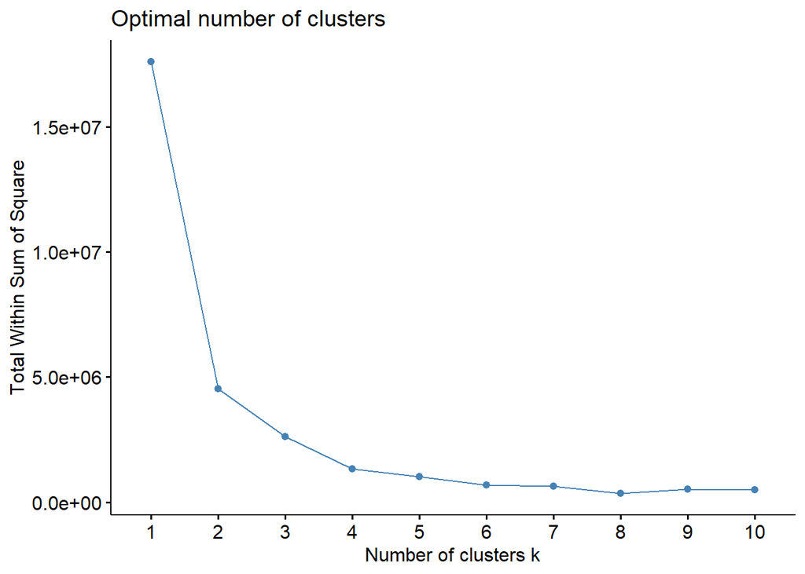

```r
# Reproducible results
set.seed(800)

# Single function to compute the “Elbow method”
fviz_nbclust(data, kmeans, method="wss")
```

## 1.3 Resultados

Calculamos los valores medios de cada clúster.

```r
# Reproducible results
set.seed(800)

# Execution of k-means with k=3
data_k3 <- kmeans(dataNorm, centers=3)

# Mean values of each cluster
aggregate(data, by=list(data_k3$cluster), mean)
```

```
##   Group.1  Alcohol Malic_Acid      Ash Ash_Alcanity Magnesium Total_Phenols
## 1       1 13.71148   1.997049 2.453770     17.28197 107.78689      2.842131
## 2       2 13.15163   3.344490 2.434694     21.43878  99.02041      1.678163
## 3       3 12.25412   1.914265 2.239118     20.07941  93.04412      2.248971
##   Flavanoids Nonflavanoid_Phenols Proanthocyanins Color_Intensity       Hue
## 1  2.9691803            0.2891803        1.922951        5.444590 1.0677049
## 2  0.7979592            0.4508163        1.163061        7.343265 0.6859184
## 3  2.0733824            0.3629412        1.601324        3.064706 1.0542059
##      OD280   Proline Customer_Segment
## 1 3.154754 1110.6393         1.032787
## 2 1.690204  627.5510         2.979592
## 3 2.788529  506.5882         2.000000
```

## 1.4 Visualizaciones

Visualización hecha con la librería GGally.

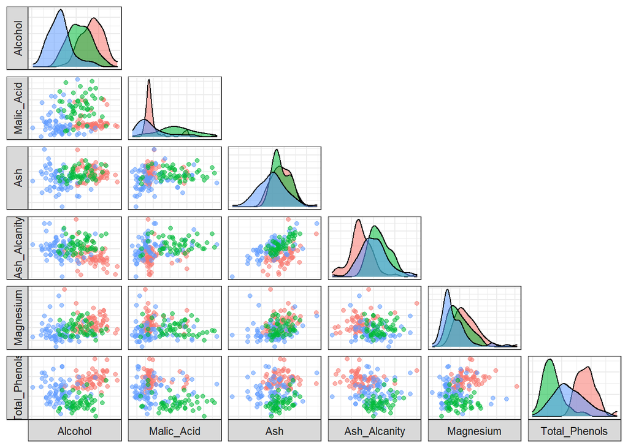

```r
# Clustering
ggpairs(cbind(data, Cluster=as.factor(data_k3$cluster)),
        columns=1:6, aes(colour=Cluster, alpha=0.5),
        lower=list(continuous="points"),
        upper=list(continuous="blank"),
        axisLabels="none", switch="both") +
        theme_bw()
```

En los siguientes gráficos puede verse muy claramente como tres grupos son los ideales para llevar a cabo la segmentación. Visualizaciones hechas con la librería factoextra.

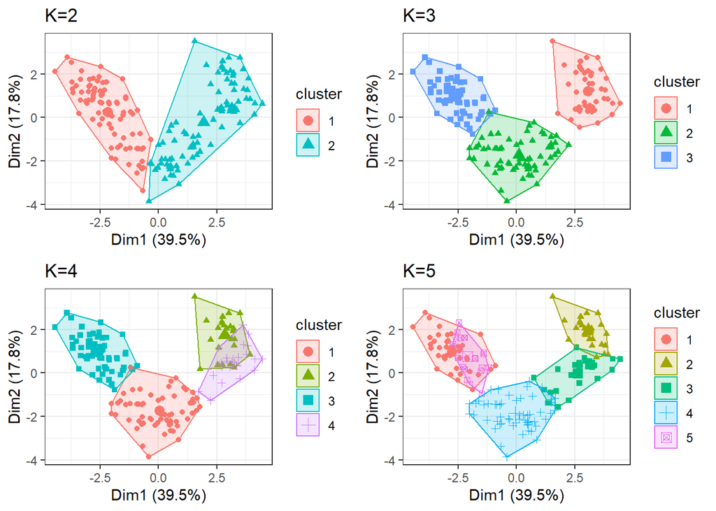

```r
# Reproducible results
set.seed(800)

# Execution of k-means
kmeans2 <- kmeans(dataNorm, centers=2)
kmeans3 <- kmeans(dataNorm, centers=3)
kmeans4 <- kmeans(dataNorm, centers=4)
kmeans5 <- kmeans(dataNorm, centers=5)

# Visualization
p1 <- fviz_cluster(kmeans2, geom="point", data=dataNorm) + ggtitle("K=2") + theme_bw()
p2 <- fviz_cluster(kmeans3, geom="point", data=dataNorm) + ggtitle("K=3") + theme_bw()
p3 <- fviz_cluster(kmeans4, geom="point", data=dataNorm) + ggtitle("K=4") + theme_bw()
p4 <- fviz_cluster(kmeans5, geom="point", data=dataNorm) + ggtitle("K=5") + theme_bw()

# Subplot
grid.arrange(p1, p2, p3, p4, nrow=2)
```

Si quisiéramos la visualización con etiquetas…

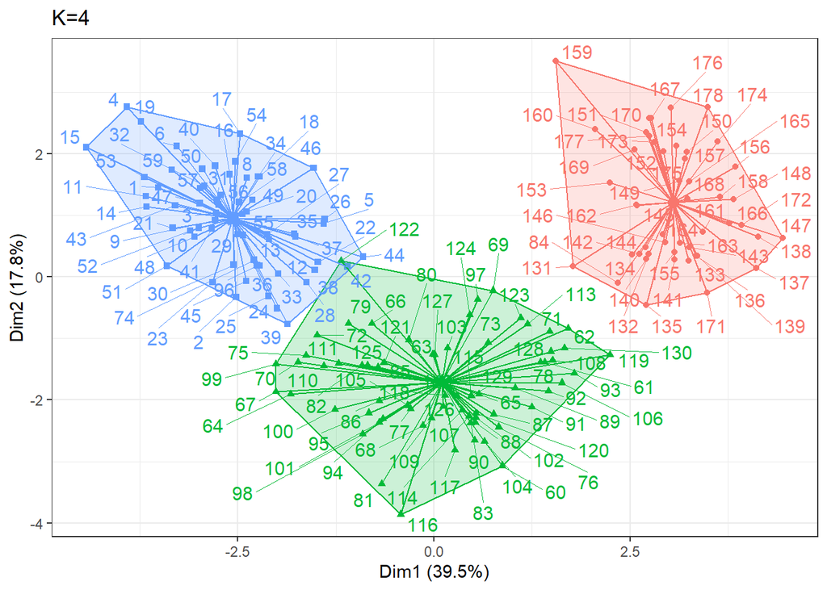

```r
# Dummy example

# Labels
rownames(dataNorm) <- 1:nrow(data)

# Visualization with labels
fviz_cluster(kmeans3, data=dataNorm, star.plot=TRUE, repel=TRUE) +
  ggtitle("K=4") +
  theme_bw() +
  theme(legend.position="none")
```

A continuación, un gráfico con los datos normalizados agrupados por clústers, con sus respectivos centroides (puntos negros).

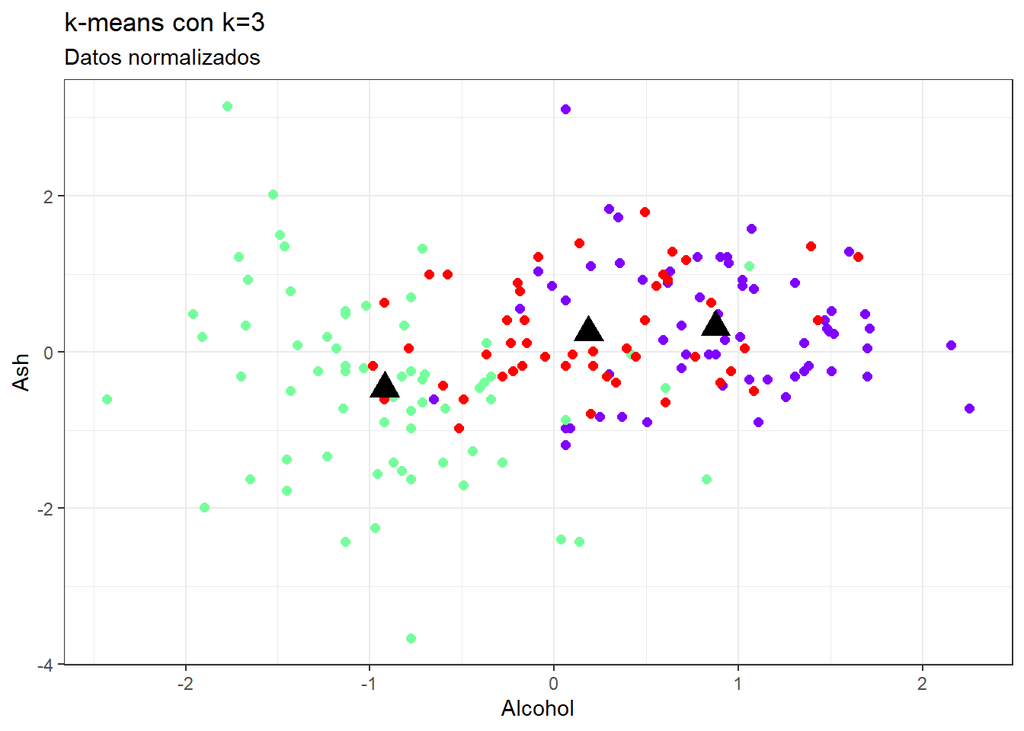

```r
# Cluster to which each point is allocated
dataNorm$cluster <- kmeans3$cluster

# Visualization
ggplot() +

  # Normalized data
  geom_point(aes(x=Alcohol, y=Ash, color=cluster), data=dataNorm, size=2, show.legend=FALSE) +

  # Centroids
  geom_point(aes(x=kmeans3$centers[, 1], y=kmeans3$centers[, 3]), color='black', size=5, shape=17) +

  labs(title="k-means con k=3", subtitle="Datos normalizados") +
  scale_colour_gradientn(colours=rainbow(4)) +
  theme_bw()
```

Con los datos originales…

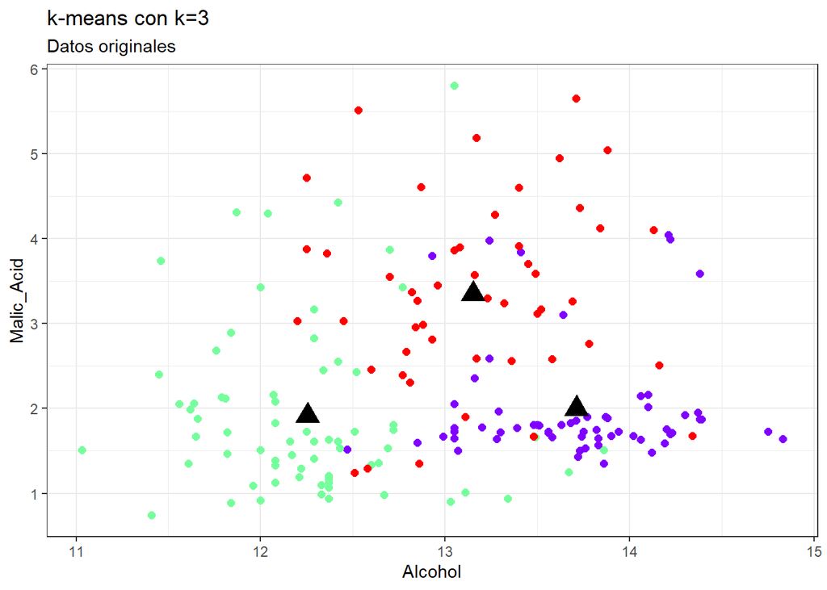

```r
# Cluster to which each point is allocated
data$cluster <- kmeans3$cluster

# Mean values of each cluster
centroids <- aggregate(data, by=list(data_k3$cluster), mean)

# Visualization
ggplot() +

  # Original data
  geom_point(aes(x=Alcohol, y=Malic_Acid, color=cluster), data=data, size=2, show.legend=FALSE) +

  # Centroids
  geom_point(aes(x=centroids[, 2], y=centroids[, 3]), color='black', size=5, shape=17) +

  labs(title="k-means con k=3", subtitle="Datos originales") +
  scale_colour_gradientn(colours=rainbow(4)) +
  theme_bw()
```

Podemos ver las diferencias entre estos dos últimos gráficos en los valores de los ejes.